# Bootstrap Example

Erin Melcon

Monday, February 23, 2015

Recall that for a non-parametric bootstrap, we are interested in estimating a value $\theta$.

A non-parametric bootstrap has the following steps:

1. Assume you have an original sample of size n. Resample from this data n times with replacement to create a bootstrap sample.
2. For this bootstrap sample, find $\hat{\theta}^B_i$, the $i^{th}$ bootstrap estimate of your statistic of interest.
3. Repeat 1 & 2 $B$ times, so that you have values $\hat{\theta}^B_1, \ldots \hat{\theta}^B_B$.

The bootstrap estimate of $\theta$ is then the average of all $B$ bootstrap samples, or $\bar{\theta}_{boot} = \frac{1}{B}\sum_{i=1}^{B} \hat{\theta}^B_i$

The standard deviation of the bootstrap estimate (or standard error of the bootstrap estimate) is then $\sqrt{\frac{1}{B-1}\sum_{i=1}^B (\bar{\theta}_{boot} - \hat{\theta}^B_i)^2}$

A parametric bootstrap assumes that you know the underlying distribution, and can generate data from that distribution using sample estimates as your parameters.

A parametric bootstrap has the following steps:

1. Assume you have an original sample of size n. Use this sample to estimate the parameters of the known distribution, and randomly generate a sample of size n from the known distribution. This is your bootstrap sample.
2. For this bootstrap sample, find $\hat{\theta}^B_i$, the $i^{th}$ bootstrap estimate of your statistic of interest.
3. Repeat 1 & 2 $B$ times, so that you have values $\hat{\theta}^B_1, \ldots \hat{\theta}^B_B$.

The bootstrap estimate of $\theta$ is then the average of all $B$ bootstrap samples, or $\bar{\theta}_{boot} = \frac{1}{B}\sum_{i=1}^{B} \hat{\theta}^B_i$

The standard deviation of the bootstrap estimate (or standard error of the bootstrap estimate) is then $\sqrt{\frac{1}{B-1}\sum_{i=1}^B (\bar{\theta}_{boot} - \hat{\theta}^B_i)^2}$

The code for this is VERY easy to implement in R.

### Example 1 : Non-parametric Bootstrap

Consider a sample from the lynx data:

```r
X = sample(as.numeric(lynx), 50)
```

We will use this sample to create bootstrap estimates of the mean, and find standard deviations of the estimates.

```r
#Getting the bootstrap sample estimates
B = 1000
all.the.BS = sapply(1:B,function(i){
  BS.sample = sample(X,length(X),replace = TRUE)
  theta.hat = mean(BS.sample)
  return(theta.hat)
})
BS.estimate = mean(all.the.BS)
BS.error = sd(all.the.BS)
results = c(BS.estimate,BS.error)
names(results) = c("Bootstrap Mean","Bootstrap Error")
results
```

```
##  Bootstrap Mean Bootstrap Error
##       1406.6357        209.2053
```

Notice we can calculate the TRUE mean of the lynx “population” and the mean of our sample:

```r
mean(as.numeric(lynx))
```

```
## [1] 1538.018
```

```r
mean(X)
```

```
## [1] 1407.14
```

We can also create a bootstrap confidence interval, by finding the $(\alpha/2)^{th}$ and $(1-\alpha/2)^{th}$ percentiles of many bootstrap estimates, and see if that interval contains the “true” lynx data mean:

```r
alpha = 0.05
BS.CI = quantile(all.the.BS, c(alpha/2, 1-alpha/2))
names(BS.CI) = c("Lower Bound","Upper Bound")
BS.CI
```

```
## Lower Bound Upper Bound
##    1015.071    1848.535
```

```r
BS.CI[1] < mean(lynx) & BS.CI[2] > mean(lynx)
```

```
## Lower Bound
##        TRUE
```

### Example 2 : Parametric bootstrap

Notice that the lynx “population” looks like it could be exponential:

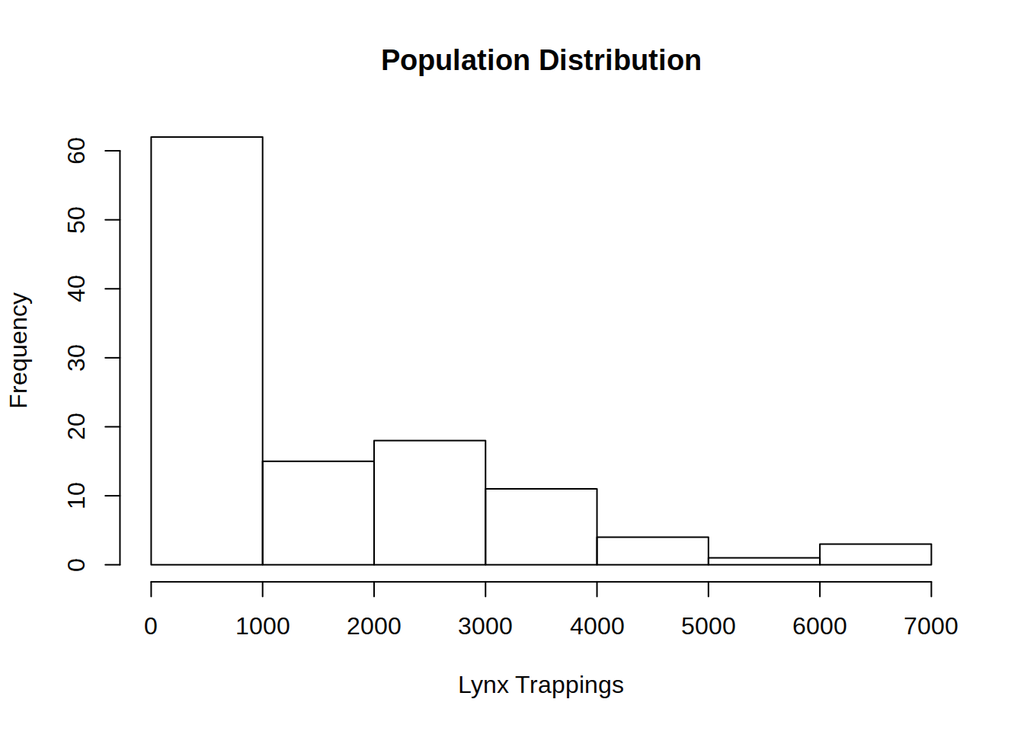

```r
hist(lynx,main = "Population Distribution",xlab = "Lynx Trappings")
```

We will generate our bootstrap samples with an exponential distribution, where we estimate the mean with the mean from our sample.

```r
para.BS = sapply(1:B,function(i){
  BS.sample = rexp(length(X), rate = 1/mean(X))
  theta.hat = mean(BS.sample)
  return(theta.hat)
})
para.estimate = mean(para.BS)
para.error = sd(para.BS)

para.results = c(para.estimate,para.error)
names(para.results) = c("Bootstrap Mean","Bootstrap Error")
para.results
```

```
##  Bootstrap Mean Bootstrap Error
##        1413.579         198.162
```

We can create a confidence interval just like before as well:

```r
alpha = 0.05
para.CI = quantile(para.BS, c(alpha/2, 1-alpha/2))
names(para.CI) = c("Lower Bound","Upper Bound")
para.CI
```

```
## Lower Bound Upper Bound
##    1046.851    1847.468
```

```r
para.CI[1] < mean(lynx) & para.CI[2] > mean(lynx)
```

```
## Lower Bound
##        TRUE
```

### Comments

If you run this code a view times, you will see that how well the bootstrap estimate does depends on how good our first sample was. Bootstrap estimates are HIGHLY dependent on the initial sample.